# Predicting Crime in DC (2015-2019)

## Introduction

I have been interested in trying to understand crime for a while now, and especially in understanding what causes crime, to therefore try to enact better policies and other solutions to reduce crime. Additionally, a simple mapping I did in a recent assignment got me thinking about what more I could do with mapped data. Many factors like socioeconomics ([in childhood](https://pubmed.ncbi.nlm.nih.gov/15225338/), [in general](https://storymaps.arcgis.com/stories/b5ab6df3741649c4bcc0a5fbd9e3b45b)), [life satisfaction](https://www.tandfonline.com/doi/full/10.1080/1068316X.2020.1849692#:~:text=We%20test%20the%20hypothesis%20that,reporting%20criminal%20and%20deviant%20acts.), and [drug use](https://www.prisonpolicy.org/blog/2017/06/28/drugs/) have been shown to affect the likelihood of individuals to commit crimes. In this project, I want to see if those trends hold for large populations, in this case, that of Washington DC. If we are unable to determine if these relationoships exist, we may still be able to answer simpler questions using other data provided to us, such as the relationships between types of crimes or general crime rate vs time, date, and location.

I got my data from DC's own Open Data Website: https://opendata.dc.gov/

Specifically:

- https://opendata.dc.gov/datasets/DCGIS::crime-incidents-in-2015/about
- https://opendata.dc.gov/datasets/DCGIS::crime-incidents-in-2016/about
- https://opendata.dc.gov/datasets/DCGIS::crime-incidents-in-2017/about
- https://opendata.dc.gov/datasets/DCGIS::crime-incidents-in-2018/about
- https://opendata.dc.gov/datasets/DCGIS::crime-incidents-in-2019/about
- https://opendata.dc.gov/datasets/DCGIS::acs-economic-characteristics-dc-census-tract/about

First, we will need to retrieve the relevant data, and then process it into how we desire. Above are the reported crimes datasets for years 2015-2019, as well as socioeconomic data from 2015-2019. I chose these years to analyze since they are the most recent years in which there is socioeconomic data collected. The crime datasets already come with many attributes, and I struggled to find relevant-enough datasets with life satisfaction or drug use metrics.

## Data Collection

First and foremost, we need the crime data. Since each year's data came separately, we also need to combine them all. I also add a year reported attribute for easy use in processing later

```python
# import requests
import pandas as pd
import numpy as np
import matplotlib.pyplot as plt
import folium
import statsmodels.api as sm
from sklearn.linear_model import LinearRegression


# Data collection and curation
dc_crime_tables = []
dc_crime_df = pd.DataFrame()

years = list(range(2015,2020))

# Make one comprehensive dataframe with every crime reported over the whole time span we're looking at
for year in years:
  dc_crime_tables.append(pd.read_csv("Crime_Incidents_in_" + str(year) + ".csv"))

  dc_crime_tables[year-2015]["Year"] = year

  # verifying that all 5 years of data have the same columns, perfect
  # print(dc_crime_tables[year].head())

  dc_crime_df = pd.concat([dc_crime_df, dc_crime_tables[year-2015]])
```

Let's quickly look at a bit of this data. The first entries will be those reported in 2015, then 2016, and so on and so forth

```python
dc_crime_df.head()
```

|  | X | Y | CCN | REPORT_DAT | SHIFT | METHOD | OFFENSE | BLOCK | XBLOCK | YBLOCK | ... | CENSUS_TRACT | VOTING_PRECINCT | LATITUDE | LONGITUDE | BID | START_DATE | END_DATE | OBJECTID | OCTO_RECORD_ID | Year |
| --- | --- | --- | --- | --- | --- | --- | --- | --- | --- | --- | --- | --- | --- | --- | --- | --- | --- | --- | --- | --- | --- |
| 0 | -76.980389 | 38.899623 | 11105327 | 2015/08/14 04:00:00+00 | MIDNIGHT | KNIFE | SEX ABUSE | 1516 - 1699 BLOCK OF BENNING ROAD NE | 401701.35 | 136862.76 | ... | 7901.0 | Precinct 81 | 38.899615 | -76.980387 | NaN | 2011/07/22 00:00:00+00 | 2011/07/22 03:00:00+00 | 153144374 | NaN | 2015 |
| 1 | -77.040088 | 38.908485 | 13134420 | 2015/07/28 04:00:00+00 | MIDNIGHT | OTHERS | SEX ABUSE | 1700 - 1799 BLOCK OF MASSACHUSETTS AVENUE NW | 396523.21 | 137847.13 | ... | 5303.0 | Precinct 15 | 38.908477 | -77.040086 | NaN | 2013/09/14 03:00:00+00 | 2013/09/14 23:00:00+00 | 153188017 | NaN | 2015 |
| 2 | -77.072880 | 38.930455 | 14158527 | 2015/01/25 05:00:00+00 | MIDNIGHT | OTHERS | SEX ABUSE | 3000 - 3199 BLOCK OF WISCONSIN AVENUE NW | 393681.01 | 140287.76 | ... | 704.0 | Precinct 28 | 38.930448 | -77.072878 | NaN | 2014/03/22 02:00:00+00 | 2014/03/22 02:05:00+00 | 153210161 | NaN | 2015 |
| 3 | -77.039957 | 38.934834 | 14174448 | 2015/01/22 14:00:00+00 | DAY | OTHERS | THEFT F/AUTO | 3400 - 3499 BLOCK OF MOUNT PLEASANT STREET NW | 396535.83 | 140772.03 | ... | 2704.0 | Precinct 40 | 38.934826 | -77.039955 | NaN | 2014/11/08 15:00:00+00 | 2014/11/10 16:08:00+00 | 153213102 | NaN | 2015 |
| 4 | -76.983992 | 38.909046 | 14200578 | 2015/01/01 06:02:00+00 | MIDNIGHT | OTHERS | THEFT F/AUTO | 1200 - 1299 BLOCK OF SIMMS PLACE NE | 401388.66 | 137908.70 | ... | 8804.0 | Precinct 78 | 38.909038 | -76.983989 | NaN | 2014/12/31 23:11:00+00 | 2014/12/31 23:30:00+00 | 153215492 | NaN | 2015 |

5 rows × 26 columns

This is somewhat interesting as the first few of these crimes committed occured much earlier than 2015. Especially with sex abuse, victims tend to not report crimes as much as victims of other crimes like theft since it may involve their private lives, create difficult social situations, and has historically been stigmatized. While we could choose to not include data reported from a different year than the one in which the sheet is on, there is still certainly crime going on unreporting, and therefore we should expect each years worth of crime reports to be missing some counts from that year. As this applies to all years, and since there are so few of these data entries, I choose to keep them in, as a stand-in for the unknown crimes being committed during each year in question.

To elaborate on what is actually in this data, the yearly crime data has the following attributes (+ year the crime was reported that we added above):

```python
print(dc_crime_df.columns)
```

```
Index(['X', 'Y', 'CCN', 'REPORT_DAT', 'SHIFT', 'METHOD', 'OFFENSE', 'BLOCK',
       'XBLOCK', 'YBLOCK', 'WARD', 'ANC', 'DISTRICT', 'PSA',
       'NEIGHBORHOOD_CLUSTER', 'BLOCK_GROUP', 'CENSUS_TRACT',
       'VOTING_PRECINCT', 'LATITUDE', 'LONGITUDE', 'BID', 'START_DATE',
       'END_DATE', 'OBJECTID', 'OCTO_RECORD_ID', 'Year'],
      dtype='object')
```

Some attributes I'm particularly interested in are the types of crimes that occurred and when crimes occurred:

```python
offense_types = dc_crime_df['OFFENSE'].unique()
shift_types = dc_crime_df['SHIFT'].unique()

print(offense_types)
print(shift_types)
```

```
['SEX ABUSE' 'THEFT F/AUTO' 'BURGLARY' 'THEFT/OTHER'
 'ASSAULT W/DANGEROUS WEAPON' 'ROBBERY' 'MOTOR VEHICLE THEFT' 'HOMICIDE'
 'ARSON']
['MIDNIGHT' 'DAY' 'EVENING']
```

Next, let's try to get socioeconomics and drug use data. We have some pretty standard socioeconomic metrics, but for drug use, the closest thing I could potentially use is liquor licenses, roughly mapping to alcohol consumption by location.

```python
economics_df = pd.read_csv("ACS_Economic_Characteristics_DC_Census_Tract.csv")
liquor_licenses_df = pd.read_csv("Liquor_Licenses.csv")

print(economics_df.head())
print(liquor_licenses_df.head())
```

```
   OBJECTID  STATEFP  COUNTYFP  TRACTCE        GEOID   NAME  \
0         1       11         1     1401  11001001401  14.01
1         2       11         1     9505  11001009505  95.05
2         3       11         1     1902  11001001902  19.02
3         4       11         1     1901  11001001901  19.01
4         5       11         1     1100  11001001100  11.00

             NAMELSAD  MTFCC FUNCSTAT    ALAND  ...  DP03_0131PE  DP03_0132PE  \
0  Census Tract 14.01  G5020        S   788095  ...          0.0          1.7
1  Census Tract 95.05  G5020        S  1032228  ...          0.0          7.2
2  Census Tract 19.02  G5020        S   877350  ...          0.0          1.8
3  Census Tract 19.01  G5020        S   769306  ...          0.0         33.5
4     Census Tract 11  G5020        S  1676650  ...          0.0          0.0

   DP03_0133PE  DP03_0134PE  DP03_0135PE  DP03_0136PE  DP03_0137PE  \
```

[output cut: 57 more lines]

## Data Processing

Next we will filter all this data to just focus on the stuff we're interested in and potentially compute new attributes we want. We'll start again witht the crime data:

```python
dc_crime_df = dc_crime_df[['Y', 'X', 'SHIFT', 'OFFENSE', 'CENSUS_TRACT',
                           'REPORT_DAT', 'START_DATE', 'END_DATE', 'Year']]
dc_crime_df.columns = ["Latitude", "Longitude", "Time Shift", "Offense",
                       "Census Tract", "Report Date", "Start Date", "End Date", "Year"]
dc_crime_df.head()
```

|  | Latitude | Longitude | Time Shift | Offense | Census Tract | Report Date | Start Date | End Date | Year |
| --- | --- | --- | --- | --- | --- | --- | --- | --- | --- |
| 0 | 38.899623 | -76.980389 | MIDNIGHT | SEX ABUSE | 7901.0 | 2015/08/14 04:00:00+00 | 2011/07/22 00:00:00+00 | 2011/07/22 03:00:00+00 | 2015 |
| 1 | 38.908485 | -77.040088 | MIDNIGHT | SEX ABUSE | 5303.0 | 2015/07/28 04:00:00+00 | 2013/09/14 03:00:00+00 | 2013/09/14 23:00:00+00 | 2015 |
| 2 | 38.930455 | -77.072880 | MIDNIGHT | SEX ABUSE | 704.0 | 2015/01/25 05:00:00+00 | 2014/03/22 02:00:00+00 | 2014/03/22 02:05:00+00 | 2015 |
| 3 | 38.934834 | -77.039957 | DAY | THEFT F/AUTO | 2704.0 | 2015/01/22 14:00:00+00 | 2014/11/08 15:00:00+00 | 2014/11/10 16:08:00+00 | 2015 |
| 4 | 38.909046 | -76.983992 | MIDNIGHT | THEFT F/AUTO | 8804.0 | 2015/01/01 06:02:00+00 | 2014/12/31 23:11:00+00 | 2014/12/31 23:30:00+00 | 2015 |

The economic characteristics dataset is especially annoying since all of its economic attributes in the file do not have descriptive names, and we therefore have to cross reference with the labels on the website to figure out which columns are what and therefore what columns we want to keep:

```python
# DP03_0095E is technically "HEALTH INSURANCE COVERAGE: Civilian noninstitutionalized population"
# but this is the closest we have to a total population count since other population counts look at more specific populations
economics_df = economics_df[["TRACTCE", "INTPTLAT", "INTPTLON", "ALAND", "DP03_0001E", "DP03_0095E", "DP03_0009PE", "DP03_0062E", "DP03_0063E", "DP03_0119PE", "GIS_ID"]]
economics_df.columns = ["Census Tract", "Latitude", "Longitude", "Area", "Population 16+", "Population", "Unemployment Rate", "Median Household Income", "Mean Household income", "Percent in Poverty", "GIS_ID"]

economics_df.head()
```

|  | Census Tract | Latitude | Longitude | Area | Population 16+ | Population | Unemployment Rate | Median Household Income | Mean Household income | Percent in Poverty | GIS_ID |
| --- | --- | --- | --- | --- | --- | --- | --- | --- | --- | --- | --- |
| 0 | 1401 | 38.965304 | -77.070607 | 788095 | 2740 | 3659 | 4.4 | 143056.0 | 242240.0 | 1.2 | ACS_Economic_DC_CensusTract_162 |
| 1 | 9505 | 38.961898 | -77.005202 | 1032228 | 3203 | 3721 | 10.9 | 81917.0 | 108672.0 | 3.0 | ACS_Economic_DC_CensusTract_32 |
| 2 | 1902 | 38.963930 | -77.015646 | 877350 | 2201 | 2544 | 5.9 | 90893.0 | 121017.0 | 1.8 | ACS_Economic_DC_CensusTract_168 |
| 3 | 1901 | 38.964685 | -77.023633 | 769306 | 3465 | 4183 | 6.1 | 98523.0 | 121894.0 | 6.8 | ACS_Economic_DC_CensusTract_167 |
| 4 | 1100 | 38.957243 | -77.077673 | 1676650 | 3907 | 4766 | 3.8 | 151250.0 | 235874.0 | 0.6 | ACS_Economic_DC_CensusTract_160 |

## Exploratory Data Analysis

#### Marking crime data on a map

Like in a [previous project](https://github.com/cmsc320/spring2022/tree/main/project4), I want to map where crimes are happening to get an initial qualitative view of things

```python
map_osm = folium.Map(location=[38.907, -77.0369], zoom_start=12)

# make different marks for the time of crime and time of day
offense_type_markers = {"ARSON":"red",
                        "ASSAULT W/DANGEROUS WEAPON":"orange",
                        "BURGLARY":"purple",
                        "HOMICIDE":"black",
                        "MOTOR VEHICLE THEFT":"green",
                        "ROBBERY":"purple",
                        "SEX ABUSE":"pink",
                        "THEFT F/AUTO":"green",
                        "THEFT/OTHER":"blue"
                        }
shift_markers = {"DAY":"certificate", "EVENING":"cloud", "MIDNIGHT":"star"}


# Iterate over all the data points and mark on regular intervals
for index, crime in dc_crime_df.iterrows():
  if (index % 300 == 0):

    folium.Marker(location = [crime["Latitude"], crime["Longitude"]],
                  popup = crime["Time Shift"].lower() + " " + crime["Offense"].lower(),
                  icon = folium.Icon(color=offense_type_markers[crime["Offense"]], icon=shift_markers[crime["Time Shift"]])
                  ).add_to(map_osm)

map_osm
```

Make this Notebook Trusted to load map: File -> Trust Notebook

[interactive chart not shown]

This map marks a pseudorandom sample of crime data data points, differentiating between the time and types of crimes, placed at the exact locations of each report, and gives us a decent inital first picture at the trends going on. The color of each marker denote the offense of the crime. The colors are:

- Red: Arson
- Orange: Assault with a dangerous weapon
- Green: Motor vehicle theft or "THEFT F/AUTO" which I presume is similar
- Blue: Other theft
- Purple: Burglary or robbery
- Pink: Sex abuse
- Black: Homicide

Additionally, the icons on each marker denote the time shift at which the offense took place ([bootstrap 3 icons](https://www.w3schools.com/icons/bootstrap_icons_glyphicons.asp)- these were limited so I had to be creative with what could represent day evening and night):

- Day: the certificate icon which looks somewhat like a sun
- Evening: Cloud icon
- Midnight: Star icon

First just looking at the positions of the markers, there is generally a lot more crime recorded near the center of DC (excluding the touristy and politically sensitive Washington Mall and surrounding areas which are generally under high security). Other areas with no crime include Rock Creek Park, the National Arboretum, and the Anacostia Naval Station.

I additionally want to look at the number of crimes and distribution of different types of crimes per year

#### Graph bar charts

```
				Number of DC Crimes by Year and Offense:
			Year:	2015	2016	2017	2018	2019
THEFT/OTHER                     14243   14555   14491   14218   15562
THEFT F/AUTO                    11308   12161   10272   11640   10730
ROBBERY                         3345    2976    2408    2398    2234
MOTOR VEHICLE THEFT             2903    2693    2177    2026    2188
ASSAULT W/DANGEROUS WEAPON      2542    2267    1850    1670    1572
BURGLARY                        2388    2124    1531    1420    1271
SEX ABUSE                       335     346     298     276     198
HOMICIDE                        160     136     116     160     164
ARSON                           18      6       5       5       8
```

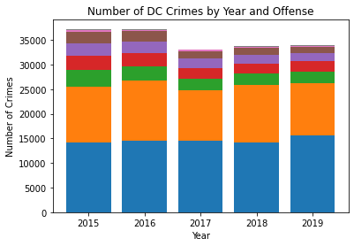

```python
# Referred a lot to these:
# https://matplotlib.org/3.5.0/gallery/misc/table_demo.html#sphx-glr-gallery-misc-table-demo-py
# https://matplotlib.org/stable/gallery/lines_bars_and_markers/bar_stacked.html

offense_counts = []
offense_types_order = []

for year in years:
  offense_types_order = dc_crime_df.loc[dc_crime_df['Year']==year]['Offense'].value_counts().keys()
  offense_counts.append(np.array(dc_crime_df.loc[dc_crime_df['Year']==year]['Offense'].value_counts()))

offense_counts = np.asarray(offense_counts)
# transpose the array from being indexed first by years then by offense type, to first by offense type and then by year
# I've now decided to keep offense counts as being first indexed by year to use in later code
# This structure feels more intuitive to me
#offense_counts = offense_counts.T

# to stack the bars on top of each other instead of all on each other
y_offset = np.zeros(len(years))


# Print out a table of the counts of different crimes types alongside the graph
print("\t\t\t\tNumber of DC Crimes by Year and Offense:")
print("\t\t\tYear:\t2015\t2016\t2017\t2018\t2019")

for offense in range(len(offense_types_order)):
  # add bars for each type of crime committed in series of years (hence the transposed array)
  plt.bar(years, offense_counts.T[offense], label=offense_types_order[offense], bottom=y_offset)
  # add the necessary offset for the set of bars for the next offense type
  y_offset = y_offset + offense_counts.T[offense]


  print('{:31s} {:<7d} {:<7d} {:<7d} {:<7d} {:<7d}'.format(offense_types_order[offense],
                                                      offense_counts.T[offense][0],
                                                      offense_counts.T[offense][1],
                                                      offense_counts.T[offense][2],
                                                      offense_counts.T[offense][3],
                                                      offense_counts.T[offense][4]))

plt.title("Number of DC Crimes by Year and Offense")
plt.xlabel("Year")
plt.ylabel("Number of Crimes")

plt.show()
```

#### More data manipulation

Looking ahead, I want to test if there is a relationship between socioeconomic factors and crime rates. To do this, I'lll need to do some more data processing: divide the counts of crimes by population, separate by census tracts, combine the socioeceonomic data, and then see if a relationship holds between attributes

```python
# Collect the number of crimes reported per area
crimes_by_tract = pd.DataFrame(dc_crime_df["Census Tract"].value_counts())
crimes_by_tract.columns = ["Number of Crimes"]
crimes_by_tract.index.name = 'Census Tract'
crimes_by_tract.index = crimes_by_tract.index.astype('int64')

crimes_by_tract.head()
```

| Census Tract | Number of Crimes |
| --- | --- |
| 5802 | 4535 |
| 10700 | 4526 |
| 4402 | 3202 |
| 11100 | 3053 |
| 9102 | 2738 |

```python
# Also reformat the socioeconomics data a little to allow us to merge
economics_df.set_index('Census Tract', inplace=True)
economics_df.head()
```

| Census Tract | Latitude | Longitude | Area | Population 16+ | Population | Unemployment Rate | Median Household Income | Mean Household income | Percent in Poverty | GIS_ID |
| --- | --- | --- | --- | --- | --- | --- | --- | --- | --- | --- |
| 1401 | 38.965304 | -77.070607 | 788095 | 2740 | 3659 | 4.4 | 143056.0 | 242240.0 | 1.2 | ACS_Economic_DC_CensusTract_162 |
| 9505 | 38.961898 | -77.005202 | 1032228 | 3203 | 3721 | 10.9 | 81917.0 | 108672.0 | 3.0 | ACS_Economic_DC_CensusTract_32 |
| 1902 | 38.963930 | -77.015646 | 877350 | 2201 | 2544 | 5.9 | 90893.0 | 121017.0 | 1.8 | ACS_Economic_DC_CensusTract_168 |
| 1901 | 38.964685 | -77.023633 | 769306 | 3465 | 4183 | 6.1 | 98523.0 | 121894.0 | 6.8 | ACS_Economic_DC_CensusTract_167 |
| 1100 | 38.957243 | -77.077673 | 1676650 | 3907 | 4766 | 3.8 | 151250.0 | 235874.0 | 0.6 | ACS_Economic_DC_CensusTract_160 |

```python
# Merge the datasets
crimes_by_tract = crimes_by_tract.merge(economics_df, left_index=True, right_index=True)
# Compute crime rate as the number of crimes committed per year per population per tract (*100 to make it a percent)
crimes_by_tract["Crime Rate"] = crimes_by_tract["Number of Crimes"]/crimes_by_tract["Population"]/len(years)*100
crimes_by_tract.head()
```

| Census Tract | Number of Crimes | Latitude | Longitude | Area | Population 16+ | Population | Unemployment Rate | Median Household Income | Mean Household income | Percent in Poverty | GIS_ID | Crime Rate |
| --- | --- | --- | --- | --- | --- | --- | --- | --- | --- | --- | --- | --- |
| 10700 | 4526 | 38.903999 | -77.041981 | 891588 | 1734 | 1768 | 5.4 | 76000.0 | 95158.0 | 0.0 | ACS_Economic_DC_CensusTract_59 | 51.199095 |
| 11100 | 3053 | 38.915861 | -76.968163 | 5718693 | 4882 | 5441 | 8.6 | 80466.0 | 100397.0 | 7.4 | ACS_Economic_DC_CensusTract_147 | 11.222202 |
| 9102 | 2738 | 38.918793 | -76.988895 | 1816287 | 3982 | 4803 | 10.8 | 47622.0 | 72047.0 | 23.7 | ACS_Economic_DC_CensusTract_149 | 11.401208 |
| 2802 | 2602 | 38.929434 | -77.034633 | 229696 | 4247 | 5047 | 8.3 | 73846.0 | 90087.0 | 27.8 | ACS_Economic_DC_CensusTract_49 | 10.311076 |
| 10100 | 2441 | 38.902694 | -77.031840 | 580133 | 2602 | 2663 | 4.8 | 94861.0 | 146045.0 | 13.7 | ACS_Economic_DC_CensusTract_113 | 18.332707 |

## Hypothesis Testing & Insight

Are there relationships in the data? I first explored the original general question I had in mind: do socioeconomic factors predict crime rates? Using the new dataset I created with crime rates and other attributes by census tract, I will take a look:

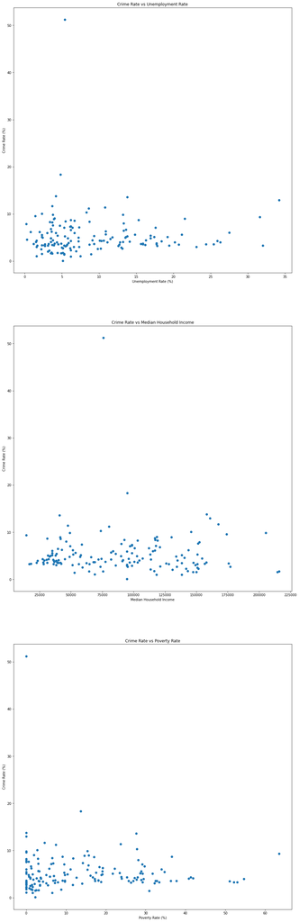

```python
fig, axs = plt.subplots(3, figsize=(15,50))
axs[0].scatter(crimes_by_tract["Unemployment Rate"], crimes_by_tract["Crime Rate"])
axs[0].set_title("Crime Rate vs Unemployment Rate")
axs[0].set_xlabel("Unemployment Rate (%)")
axs[0].set_ylabel("Crime Rate (%)")

axs[1].scatter(crimes_by_tract["Median Household Income"], crimes_by_tract["Crime Rate"])
axs[1].set_title("Crime Rate vs Median Household Income")
axs[1].set_xlabel("Median Household Income")
axs[1].set_ylabel("Crime Rate (%)")

axs[2].scatter(crimes_by_tract["Percent in Poverty"], crimes_by_tract["Crime Rate"])
axs[2].set_title("Crime Rate vs Poverty Rate")
axs[2].set_xlabel("Poverty Rate (%)")
axs[2].set_ylabel("Crime Rate (%)")
```

If there were a relationship between crime rate and the socioeconomic indicators in this data set, unemployment rate, household income, and poverty rate, then these scatterplots should show it. However, in all three it looks like crime rate does not vary with respect to any of the three. We can verify this with a linear regression test, but also probably want to remove the one massive outlier: tract 10700 with a crime rate over 50%. I also remove the rows where any of these factors do not have correct data (NaN):

```python
crimes_by_tract_filtered = crimes_by_tract.drop(10700)
crimes_by_tract_filtered = crimes_by_tract_filtered.dropna()

crimes_by_tract_filtered.head()
```

| Census Tract | Number of Crimes | Latitude | Longitude | Area | Population 16+ | Population | Unemployment Rate | Median Household Income | Mean Household income | Percent in Poverty | GIS_ID | Crime Rate |
| --- | --- | --- | --- | --- | --- | --- | --- | --- | --- | --- | --- | --- |
| 11100 | 3053 | 38.915861 | -76.968163 | 5718693 | 4882 | 5441 | 8.6 | 80466.0 | 100397.0 | 7.4 | ACS_Economic_DC_CensusTract_147 | 11.222202 |
| 9102 | 2738 | 38.918793 | -76.988895 | 1816287 | 3982 | 4803 | 10.8 | 47622.0 | 72047.0 | 23.7 | ACS_Economic_DC_CensusTract_149 | 11.401208 |
| 2802 | 2602 | 38.929434 | -77.034633 | 229696 | 4247 | 5047 | 8.3 | 73846.0 | 90087.0 | 27.8 | ACS_Economic_DC_CensusTract_49 | 10.311076 |
| 10100 | 2441 | 38.902694 | -77.031840 | 580133 | 2602 | 2663 | 4.8 | 94861.0 | 146045.0 | 13.7 | ACS_Economic_DC_CensusTract_113 | 18.332707 |
| 202 | 2321 | 38.906305 | -77.069636 | 776437 | 4422 | 4709 | 3.8 | 205326.0 | 270622.0 | 0.0 | ACS_Economic_DC_CensusTract_109 | 9.857719 |

Now that we've filtered the data for outliers, let's try plotting them again, and also include linear regressions. If there is a relationship, then the regressions will be able to numerically show it

```
Crime Rate vs Unemployment Rate Model:
                 Results: Ordinary least squares
=================================================================
Model:              OLS              Adj. R-squared:     -0.001
Dependent Variable: Crime Rate       AIC:                748.1755
Date:               2022-05-18 02:23 BIC:                754.2101
No. Observations:   151              Log-Likelihood:     -372.09
Df Model:           1                F-statistic:        0.8601
Df Residuals:       149              Prob (F-statistic): 0.355
R-squared:          0.006            Scale:              8.1970
-------------------------------------------------------------------
            Coef.    Std.Err.      t      P>|t|     [0.025   0.975]
-------------------------------------------------------------------
const       4.8222     0.3770   12.7907   0.0000    4.0772   5.5672
x1          0.0304     0.0328    0.9274   0.3552   -0.0344   0.0953
-----------------------------------------------------------------
Omnibus:             50.120       Durbin-Watson:          0.904
Prob(Omnibus):       0.000        Jarque-Bera (JB):       108.761
Skew:                1.452        Prob(JB):               0.000
Kurtosis:            5.975        Condition No.:          19
=================================================================

Crime Rate vs Median Household Income Model:
                 Results: Ordinary least squares
=================================================================
Model:              OLS              Adj. R-squared:     -0.006
Dependent Variable: Crime Rate       AIC:                748.9824
Date:               2022-05-18 02:23 BIC:                755.0170
No. Observations:   151              Log-Likelihood:     -372.49
Df Model:           1                F-statistic:        0.06140
Df Residuals:       149              Prob (F-statistic): 0.805
R-squared:          0.000            Scale:              8.2409
--------------------------------------------------------------------
         Coef.     Std.Err.      t       P>|t|      [0.025    0.975]
--------------------------------------------------------------------
const    4.9872      0.5013    9.9477    0.0000     3.9965    5.9778
x1       0.0000      0.0000    0.2478    0.8046    -0.0000    0.0000
-----------------------------------------------------------------
Omnibus:             48.185       Durbin-Watson:          0.925
Prob(Omnibus):       0.000        Jarque-Bera (JB):       102.082
```

[output cut: 11 more lines]

```
No. Observations:   151              Log-Likelihood:     -372.32
Df Model:           1                F-statistic:        0.4067
Df Residuals:       149              Prob (F-statistic): 0.525
R-squared:          0.003            Scale:              8.2219
-------------------------------------------------------------------
            Coef.    Std.Err.      t      P>|t|     [0.025   0.975]
-------------------------------------------------------------------
const       4.9507     0.3274   15.1232   0.0000    4.3038   5.5975
x1          0.0108     0.0170    0.6378   0.5246   -0.0227   0.0443
-----------------------------------------------------------------
Omnibus:             50.195       Durbin-Watson:          0.937
Prob(Omnibus):       0.000        Jarque-Bera (JB):       108.324
Skew:                1.458        Prob(JB):               0.000
Kurtosis:            5.951        Condition No.:          27
=================================================================
```

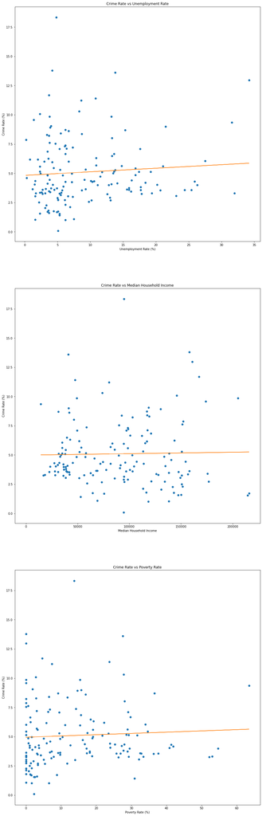

```python
fig, axs = plt.subplots(3, figsize=(15,50))

# Plot the filtered data of crime vs unemployment rates
axs[0].scatter(crimes_by_tract_filtered["Unemployment Rate"], crimes_by_tract_filtered["Crime Rate"])
axs[0].set_title("Crime Rate vs Unemployment Rate")
axs[0].set_xlabel("Unemployment Rate (%)")
axs[0].set_ylabel("Crime Rate (%)")

# Compute the linear regression
unemployment = sm.add_constant(crimes_by_tract_filtered["Unemployment Rate"].values.reshape(-1,1))
mod_unemployment = sm.OLS(crimes_by_tract_filtered["Crime Rate"], unemployment)
fii_unemployment = mod_unemployment.fit()
print("Crime Rate vs Unemployment Rate Model:")
print(fii_unemployment.summary2())

# Get the important data
unemployment_r2 = fii_unemployment.rsquared
unemployment_model = fii_unemployment.params
unemployment_p = fii_unemployment.f_pvalue

# Add the regression line to the plot
axs[0].plot(unemployment, unemployment_model[1]*unemployment+unemployment_model[0])


# Repeat for median household income and percent in poverty
axs[1].scatter(crimes_by_tract_filtered["Median Household Income"], crimes_by_tract_filtered["Crime Rate"])
axs[1].set_title("Crime Rate vs Median Household Income")
axs[1].set_xlabel("Median Household Income")
axs[1].set_ylabel("Crime Rate (%)")

income = sm.add_constant(crimes_by_tract_filtered["Median Household Income"].values.reshape(-1,1))
mod_income = sm.OLS(crimes_by_tract_filtered["Crime Rate"], income)
fii_income = mod_income.fit()
print("Crime Rate vs Median Household Income Model:")
print(fii_income.summary2())

income_r2 = fii_income.rsquared
income_model = fii_income.params
income_p = fii_income.f_pvalue

axs[1].plot(income, income_model[1]*income+income_model[0])


axs[2].scatter(crimes_by_tract_filtered["Percent in Poverty"], crimes_by_tract_filtered["Crime Rate"])
axs[2].set_title("Crime Rate vs Poverty Rate")
axs[2].set_xlabel("Poverty Rate (%)")
axs[2].set_ylabel("Crime Rate (%)")

poverty = sm.add_constant(crimes_by_tract_filtered["Percent in Poverty"].values.reshape(-1,1))
mod_poverty = sm.OLS(crimes_by_tract_filtered["Crime Rate"], poverty)
fii_poverty = mod_poverty.fit()
print("Crime Rate vs Poverty Rate Model:")
print(fii_poverty.summary2())

poverty_r2 = fii_poverty.rsquared
poverty_model = fii_poverty.params
poverty_p = fii_poverty.f_pvalue

axs[2].plot(poverty, poverty_model[1]*poverty+poverty_model[0])
```

These still clearly show a lack of a relationship. Just to confirm, we can look at the p-values for each of these as well. The p-value represents the likelihood that the variance in crime rate due to each of these variables could occur randomly if they had no relationship. If the p-value is greater than 0.05, or 5%, and I do not reject the null hypothesis that there is no relationship. If the p-value is less than 0.05, I reject the null hypothesis, meaning that there is a high likelihood that there is actually a relationship between the variables.

```python
print("Crime Rate vs Unemployment Rate Regression p-value: " + str(round(unemployment_p, 3)))
print("Crime Rate vs Median Household Income Regression p-value: " + str(round(income_p, 3)))
print("Crime Rate vs Poverty Rate Regression p-value: " + str(round(poverty_p, 3)))
```

```
Crime Rate vs Unemployment Rate Regression p-value: 0.355
Crime Rate vs Median Household Income Regression p-value: 0.805
Crime Rate vs Poverty Rate Regression p-value: 0.525
```

For all three, the p-values are significantly larger than 0.05, showing it is highly unlikely there is a relationship. The R-squared values are also close to 0, meaning that near 0 of the variance in crime rate is explained due to variance in the variables:

```python
print("Crime Rate vs Unemployment Rate Regression R^2: " + str(round(unemployment_r2, 3)))
print("Crime Rate vs Median Household Income Regression R^2: " + str(round(income_r2, 3)))
print("Crime Rate vs Poverty Rate Regression R^2: " + str(round(poverty_r2, 3)))
```

```
Crime Rate vs Unemployment Rate Regression R^2: 0.006
Crime Rate vs Median Household Income Regression R^2: 0.0
Crime Rate vs Poverty Rate Regression R^2: 0.003
```

We can confidently conclude that there is no relationship here. It is also apparent that these rate seems way to high so I also first verify that our population is correct:

```python
crimes_by_tract["Population"].sum()
```

```
542570
```

This is on the same order of magnitude and not so far off from the DC Population in 2020 (nearest data available) at 689,545 (https://www.census.gov/quickfacts/DC), so it seems like these rates may actually be correct or close to correct. This was probably still higher than I expected because typical crime rates reported are violent crime rates, which does not include the two most common types of crimes reported.

As a result, I now wonder if there is more of a relationship just in violent crime. Perhaps more minor and less confrontational crimes, namely theft, are not as strongly affected by socioeconomics as others like homicide. This requires building nother dataset of just the violent crimes by tract, and I will use the [official categorization of violent crimes](https://dcatlas.dcgis.dc.gov/crimecards/). I will now initially remove the NaN rows, but not the outlier from last time

```python
# Collect the number of violent crimes only reported per area
violent_crimes_by_tract = pd.DataFrame(dc_crime_df["Census Tract"].loc[dc_crime_df["Offense"]==
  ("ASSAULT W/DANGEROUS WEAPON" or "HOMICIDE" or "ROBBERY" or "SEX ABUSE")].value_counts())
violent_crimes_by_tract.columns = ["Number of Crimes"]
violent_crimes_by_tract.index.name = 'Census Tract'
violent_crimes_by_tract.index = violent_crimes_by_tract.index.astype('int64')

violent_crimes_by_tract = violent_crimes_by_tract.merge(economics_df, left_index=True, right_index=True)
violent_crimes_by_tract["Crime Rate"] = violent_crimes_by_tract["Number of Crimes"]/violent_crimes_by_tract["Population"]/len(years)*100

violent_crimes_by_tract_filtered = violent_crimes_by_tract.dropna()

violent_crimes_by_tract.head()
```

| Census Tract | Number of Crimes | Latitude | Longitude | Area | Population 16+ | Population | Unemployment Rate | Median Household Income | Mean Household income | Percent in Poverty | GIS_ID | Crime Rate |
| --- | --- | --- | --- | --- | --- | --- | --- | --- | --- | --- | --- | --- |
| 7601 | 204 | 38.871633 | -76.979818 | 1115359 | 4167 | 5121 | 13.3 | 39492.0 | 65764.0 | 18.4 | ACS_Economic_DC_CensusTract_106 | 0.796719 |
| 10400 | 203 | 38.851251 | -77.000905 | 2607546 | 3566 | 5059 | 21.1 | 35104.0 | 50766.0 | 19.1 | ACS_Economic_DC_CensusTract_2 | 0.802530 |
| 9811 | 176 | 38.826651 | -76.998459 | 467504 | 3265 | 4633 | 20.7 | 31084.0 | 56086.0 | 37.7 | ACS_Economic_DC_CensusTract_150 | 0.759767 |
| 11100 | 173 | 38.915861 | -76.968163 | 5718693 | 4882 | 5441 | 8.6 | 80466.0 | 100397.0 | 7.4 | ACS_Economic_DC_CensusTract_147 | 0.635913 |
| 7703 | 173 | 38.886322 | -76.947455 | 1017741 | 4949 | 7050 | 19.4 | 28231.0 | 42505.0 | 33.4 | ACS_Economic_DC_CensusTract_135 | 0.490780 |

These crime rates now look much more reasonable. Plotting these with regressions:

```
Crime Rate vs Unemployment Rate Model:
                 Results: Ordinary least squares
=================================================================
Model:              OLS              Adj. R-squared:     0.465
Dependent Variable: Crime Rate       AIC:                24.2537
Date:               2022-05-18 02:23 BIC:                30.2882
No. Observations:   151              Log-Likelihood:     -10.127
Df Model:           1                F-statistic:        131.2
Df Residuals:       149              Prob (F-statistic): 3.50e-22
R-squared:          0.468            Scale:              0.067853
-------------------------------------------------------------------
            Coef.    Std.Err.      t      P>|t|     [0.025   0.975]
-------------------------------------------------------------------
const       0.0468     0.0343    1.3655   0.1741   -0.0209   0.1146
x1          0.0342     0.0030   11.4536   0.0000    0.0283   0.0401
-----------------------------------------------------------------
Omnibus:             128.678      Durbin-Watson:         1.656
Prob(Omnibus):       0.000        Jarque-Bera (JB):      1854.062
Skew:                2.967        Prob(JB):              0.000
Kurtosis:            19.108       Condition No.:         19
=================================================================

Crime Rate vs Median Household Income Model:
                 Results: Ordinary least squares
=================================================================
Model:              OLS              Adj. R-squared:     0.203
Dependent Variable: Crime Rate       AIC:                84.3603
Date:               2022-05-18 02:23 BIC:                90.3948
No. Observations:   151              Log-Likelihood:     -40.180
Df Model:           1                F-statistic:        39.18
Df Residuals:       149              Prob (F-statistic): 3.91e-09
R-squared:          0.208            Scale:              0.10103
-------------------------------------------------------------------
           Coef.    Std.Err.      t      P>|t|     [0.025    0.975]
-------------------------------------------------------------------
const      0.6641     0.0557   11.9254   0.0000    0.5541    0.7742
x1        -0.0000     0.0000   -6.2593   0.0000   -0.0000   -0.0000
-----------------------------------------------------------------
Omnibus:             191.750      Durbin-Watson:         1.685
Prob(Omnibus):       0.000        Jarque-Bera (JB):      9230.665
```

[output cut: 11 more lines]

```
No. Observations:   151              Log-Likelihood:     -40.469
Df Model:           1                F-statistic:        38.46
Df Residuals:       149              Prob (F-statistic): 5.23e-09
R-squared:          0.205            Scale:              0.10142
--------------------------------------------------------------------
          Coef.     Std.Err.      t       P>|t|     [0.025    0.975]
--------------------------------------------------------------------
const     0.1978      0.0363    5.4483    0.0000    0.1260    0.2695
x1        0.0117      0.0019    6.2015    0.0000    0.0079    0.0154
-----------------------------------------------------------------
Omnibus:             185.603      Durbin-Watson:         1.652
Prob(Omnibus):       0.000        Jarque-Bera (JB):      7535.396
Skew:                4.678        Prob(JB):              0.000
Kurtosis:            36.319       Condition No.:         27
=================================================================
```

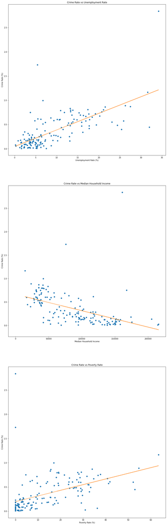

```python
fig, axs = plt.subplots(3, figsize=(15,50))

# Plot the filtered data of crime vs unemployment rates
axs[0].scatter(violent_crimes_by_tract_filtered["Unemployment Rate"], violent_crimes_by_tract_filtered["Crime Rate"])
axs[0].set_title("Crime Rate vs Unemployment Rate")
axs[0].set_xlabel("Unemployment Rate (%)")
axs[0].set_ylabel("Crime Rate (%)")

# Compute the linear regression
unemployment = sm.add_constant(violent_crimes_by_tract_filtered["Unemployment Rate"].values.reshape(-1,1))
mod_unemployment = sm.OLS(violent_crimes_by_tract_filtered["Crime Rate"], unemployment)
fii_unemployment = mod_unemployment.fit()
print("Crime Rate vs Unemployment Rate Model:")
print(fii_unemployment.summary2())

# Get the important data
unemployment_r2 = fii_unemployment.rsquared
unemployment_model = fii_unemployment.params
unemployment_p = fii_unemployment.f_pvalue

# Add the regression line to the plot
axs[0].plot(unemployment, unemployment_model[1]*unemployment+unemployment_model[0])


# Repeat for median household income and percent in poverty
axs[1].scatter(violent_crimes_by_tract_filtered["Median Household Income"], violent_crimes_by_tract_filtered["Crime Rate"])
axs[1].set_title("Crime Rate vs Median Household Income")
axs[1].set_xlabel("Median Household Income")
axs[1].set_ylabel("Crime Rate (%)")

income = sm.add_constant(violent_crimes_by_tract_filtered["Median Household Income"].values.reshape(-1,1))
mod_income = sm.OLS(violent_crimes_by_tract_filtered["Crime Rate"], income)
fii_income = mod_income.fit()
print("Crime Rate vs Median Household Income Model:")
print(fii_income.summary2())

income_r2 = fii_income.rsquared
income_model = fii_income.params
income_p = fii_income.f_pvalue

axs[1].plot(income, income_model[1]*income+income_model[0])


axs[2].scatter(violent_crimes_by_tract_filtered["Percent in Poverty"], violent_crimes_by_tract_filtered["Crime Rate"])
axs[2].set_title("Crime Rate vs Poverty Rate")
axs[2].set_xlabel("Poverty Rate (%)")
axs[2].set_ylabel("Crime Rate (%)")

poverty = sm.add_constant(violent_crimes_by_tract_filtered["Percent in Poverty"].values.reshape(-1,1))
mod_poverty = sm.OLS(violent_crimes_by_tract_filtered["Crime Rate"], poverty)
fii_poverty = mod_poverty.fit()
print("Crime Rate vs Poverty Rate Model:")
print(fii_poverty.summary2())

poverty_r2 = fii_poverty.rsquared
poverty_model = fii_poverty.params
poverty_p = fii_poverty.f_pvalue

axs[2].plot(poverty, poverty_model[1]*poverty+poverty_model[0])
```

It is immediately apparent that these relationships are much stronger. Looking at their p-values and r-squared values:

```python
print("Crime Rate vs Unemployment Rate Regression p-value: " + str(unemployment_p))
print("Crime Rate vs Unemployment Rate Regression R^2: " + str(round(unemployment_r2, 3)))

print("Crime Rate vs Median Household Income Regression p-value: " + str(income_p))
print("Crime Rate vs Median Household Income Regression R^2: " + str(round(income_r2, 3)))

print("Crime Rate vs Poverty Rate Regression p-value: " + str(poverty_p))
print("Crime Rate vs Poverty Rate Regression R^2: " + str(round(poverty_r2, 3)))
```

```
Crime Rate vs Unemployment Rate Regression p-value: 3.499049258752198e-22
Crime Rate vs Unemployment Rate Regression R^2: 0.468
Crime Rate vs Median Household Income Regression p-value: 3.907650736380775e-09
Crime Rate vs Median Household Income Regression R^2: 0.208
Crime Rate vs Poverty Rate Regression p-value: 5.2346943181211586e-09
Crime Rate vs Poverty Rate Regression R^2: 0.205
```

The p-values are all on the order of 10^-9 or less, meaning that the chance that you would see such variation in violent crime rate due to random chance is less than a 10^-7%, less likely than [getting attacked by a shark in the US](https://www.floridamuseum.ufl.edu/shark-attacks/odds/compare-risk/death/). I can therefore reject the null hypothesis that there is no relationship between these variables, as the data strongly supports there being a relationship between them. The r-squared values also show that about 46.8% of the variance in crime data can be attributed to variance in unemployment rate. Independently, 20.8% can be attributed to variance in median household income, and 20.5% can be attributed to variance in poverty rate.

This raises yet another question of: how co-related are these attributes? We can perform a multiregression to find out

```python
socioeconomic_predictors = sm.add_constant(violent_crimes_by_tract_filtered[["Unemployment Rate", "Median Household Income", "Percent in Poverty"]])
mod_socioeconomic_predictors = sm.OLS(violent_crimes_by_tract_filtered["Crime Rate"], socioeconomic_predictors)
fii_socioeconomic_predictors = mod_socioeconomic_predictors.fit()
print("Crime Rate vs Socioeconomic Predictors Model:")
print(fii_socioeconomic_predictors.summary2())
```

```
Crime Rate vs Socioeconomic Predictors Model:
                   Results: Ordinary least squares
======================================================================
Model:                 OLS               Adj. R-squared:      0.465
Dependent Variable:    Crime Rate        AIC:                 26.0455
Date:                  2022-05-18 02:23  BIC:                 38.1146
No. Observations:      151               Log-Likelihood:      -9.0227
Df Model:              3                 F-statistic:         44.50
Df Residuals:          147               Prob (F-statistic):  1.60e-20
R-squared:             0.476             Scale:               0.067778
----------------------------------------------------------------------
                         Coef.  Std.Err.    t    P>|t|   [0.025 0.975]
----------------------------------------------------------------------
const                    0.1274   0.0986  1.2924 0.1982 -0.0674 0.3223
Unemployment Rate        0.0371   0.0045  8.2118 0.0000  0.0282 0.0460
Median Household Income -0.0000   0.0000 -0.8523 0.3954 -0.0000 0.0000
Percent in Poverty      -0.0039   0.0027 -1.4690 0.1440 -0.0092 0.0014
----------------------------------------------------------------------
Omnibus:              116.739        Durbin-Watson:           1.614
Prob(Omnibus):        0.000          Jarque-Bera (JB):        1363.558
Skew:                 2.661          Prob(JB):                0.000
Kurtosis:             16.726         Condition No.:           463646
======================================================================
* The condition number is large (5e+05). This might indicate
strong multicollinearity or other numerical problems.
```

While the F-statistic probability is still very low (1.60e-20) showing that there is likely a relationship, the p-values for individual variables has gone up significantly and the condition number is very high (463646), meaning that there is large collinearity between economic factors. Additionally, the R^2 has only risen to 47.6%, meaning that 47.6% of the crime rate variance is attributable to these factors, not much more than just unemployment rate alone. This model is therefore unnecessary, and the rest of the variance in crime rate is likely due to other factors.

One wrinkle in this analysis that came to mind while performing it is that people are not necessarily committing crimes where they live. If for example you wanted to kill some coworkers, you would probably do that where you work, which may be somewhere completely different from where you live. Any movement of this kind is not reflected, and therefore what this is showing is not that people who live in areas with higher unemployment necessarily commit more crime, just that more crime is committed in areas with higher unemployment, whether by residents or nonresidents.